# London Tube

Simon Schmetz - Paola Carolina Suarez  
Network Analysis  
Master in Statistics for Data Science  
Universidad Carlos III de Madrid

Data Source: https://github.com/jaron/railgraph

## Introduction

The "London Underground Network" refers to the metro system of London, UK, encompassing its stations and the connections between them. The network consists of 309 vertices (representing stations), and 370 edges (representing the metro line connections between stations). Notably, multiple metro lines can connect to the same station, resulting in multiple edges. As an undirected network, each edge signifies a bidirectional connection, meaning travel is possible in both directions between stations.

## Data loading and cleanning

The following initial part will be for loading the Network and enriching the nodes with usage data from a seperate dataset.

```python
# Load Libraries
import pandas as pd
import matplotlib.pyplot as plt
import numpy as np
import random

import contextily as ctx
import networkx as nx
import igraph as ig

from networkx.algorithms.community import greedy_modularity_communities
from networkx.algorithms.community.quality import modularity

from networkx.algorithms.community import label_propagation_communities
from networkx.algorithms.community import girvan_newman

import community.community_louvain as community_louvain
```

Loading the Network and extracting the labels of the Stations, as they are going to be used as a way to named the vertex of the network.

```python
#Read the Network and extract geographic positions
G = nx.read_graphml('data/london_tube/tubeDLR.graphml')
labels = nx.get_node_attributes(G, 'label')
pos_geo = {node: (float(data['longitude']), float(data['latitude'])) for node, data in G.nodes(data=True)}
```

Remove node attributes that were delivered with the network.

```python
# Remove unwanted attributes
attributes_to_remove = [
    'Betweenness Centrality', 'Closeness Centrality', 'Clustering Coefficient',
    'Degree', 'Eccentricity', 'Eigenvector Centrality', 'In-Degree',
    'Number of triangles', 'Out-Degree', 'PageRank', 'b','g',
    'latitude_copy', 'longitude_copy', 'r', 'size', 'x', 'y','displyName'
]

for node, data in G.nodes(data=True):
    for attr in attributes_to_remove:
        data.pop(attr, None)
```

To further enrich the "London Underground Network", a seperate Dataset is taken, it contains the average entry and exit values from most of the stations (vertex) in our Network and add theses to our nodes. To do so, we first remove all stations where no numbers are available, which turns out to corresponds to the Docklands Light Railway (DLR) and thus can be knowingly discarded.

```python
### Add Usage Data
usage_data = pd.read_csv('data/london_tube/2017_Entry_Exit.csv')

# Feature data modification
usage_data['Avg_Exit_Weekend'] = usage_data[['Exit_Saturday', 'Exit_Sunday']].mean(axis=1)
usage_data['Avg_Entry_Weekend'] = usage_data[['Entry_Saturday', 'Entry_Sunday']].mean(axis=1)

usage_data.drop(columns=['Entry_Saturday', 'Entry_Sunday', 'Exit_Saturday', 'Exit_Sunday','Note','Borough','AnnualEntryExit_Mill'], inplace=True)

# Define mapping from non-standard to standard names
station_name_corrections = {
    'Edgware Road (Cir)': 'Edgware Road',
    'Kew Gardens': 'Kew Gardens (London)',
    "Shepherd's Bush (H&C)": "Shepherd's Bush Market",
    "Shepherd's Bush (Cen)": "Shepherd's Bush",
    'Hammersmith (Dis)': 'Hammersmith (Piccadilly and District lines)',
    'Hammersmith (H&C)': 'Hammersmith (Hammersmith & City and Circle lines)',
    "St. John's Wood": "St John's Wood",
    'Bank & Monument': 'Bank-Monument',
    'Totteridge & Whetstone': 'Totteridge and Whetstone',
    'Paddington': 'London Paddington',
    'Richmond': 'Richmond (London)',
    'Heathrow Terminals 123': 'Heathrow Terminals 1, 2, 3',
    'Edgware Road (Bak)': 'Edgware Road (Bakerloo line)',
    'Victoria': 'London Victoria'
}

# Apply corrections to df.Stations
usage_data['Station'] = usage_data['Station'].replace(station_name_corrections)


# Filter nodes in the graph that are available in usage_data
stations_in_usage_data = set(usage_data['Station'])
nodes_to_keep = [node for node, data in G.nodes(data=True) if data.get('label') in stations_in_usage_data]

# Identify stations to be dropped
stations_to_drop = [labels[node] for node, data in G.nodes(data=True) if data.get('label') not in stations_in_usage_data]


# Create a subgraph with only the nodes to keep
G = G.subgraph(nodes_to_keep).copy()

# Add Entry_Week, Exit_Week, Avg_Exit_Weekend, Avg_Entry_Weekend to the attributes of the remaining nodes
for node, data in G.nodes(data=True):
    station_label = data.get('label')
    if station_label in stations_in_usage_data:
        station_data = usage_data[usage_data['Station'] == station_label].iloc[0]
        data['Entry_Week'] = station_data['Entry_Week']
        data['Exit_Week'] = station_data['Exit_Week']
        data['Avg_Exit_Weekend'] = station_data['Avg_Exit_Weekend']
        data['Avg_Entry_Weekend'] = station_data['Avg_Entry_Weekend']

        # Remove edges connected to nodes that are not in the filtered graph
        G.remove_edges_from([(u, v) for u, v in G.edges() if u not in nodes_to_keep or v not in nodes_to_keep])
```

The Euclidean Distance between Nodes as a attribute of the arcs using longitude/latitude of the nodes.

```python
# Add "dist" attribute to each edge based on the euclidean distance between nodes in kilometers
for u, v, data in G.edges(data=True):
    lon1, lat1 = pos_geo[u]
    lon2, lat2 = pos_geo[v]
    distance = np.sqrt((lon2 - lon1)**2 + (lat2 - lat1)**2) * 111  # Convert radiants to kilometers
    data['dist'] = distance
```

Finally , the working "London Underground Network" is ready to be used for the upcoming dofferent analysis. Here it is listed the nodes (vertex) and edges (links) attributes.

```python
# List Attributes

# Nodes
unique_keys = set().union(*(data.keys() for _, data in G.nodes(data=True)))
print("Unique Node Attributes:")
for key in sorted(unique_keys):
    print(f" - {key}")

# Edges
unique_edge_keys = set().union(*(data.keys() for _, _, data in G.edges(data=True)))
print("\nUnique Edge Attributes:")
for key in sorted(unique_edge_keys):
    print(f" - {key}")
```

```
Unique Node Attributes:
 - Avg_Entry_Weekend
 - Avg_Exit_Weekend
 - Entry_Week
 - Exit_Week
 - displayName
 - label
 - latitude
 - longitude
 - stationReference

Unique Edge Attributes:
 - Neo4j Relationship Type
 - dist
 - line
 - weight
```

## Network properties

The basic properties of the "London Underground Network" are analysed to get a general idea of the characteristics of it. The initial step is to plot the network with the node position corresponding to the longitude and latitude values into a map of the City of London to get a general feel for the geography underlying the network. After plotting visualy the grahp, its clear how the Network consist out of arms corresponding to the connection between nodes and egdes in the outside area of the city center, also its highligted a concentration of nodes, as they are metro stations, where changes between lines are possible. Therefore, we are in the presence of a transportation Network.

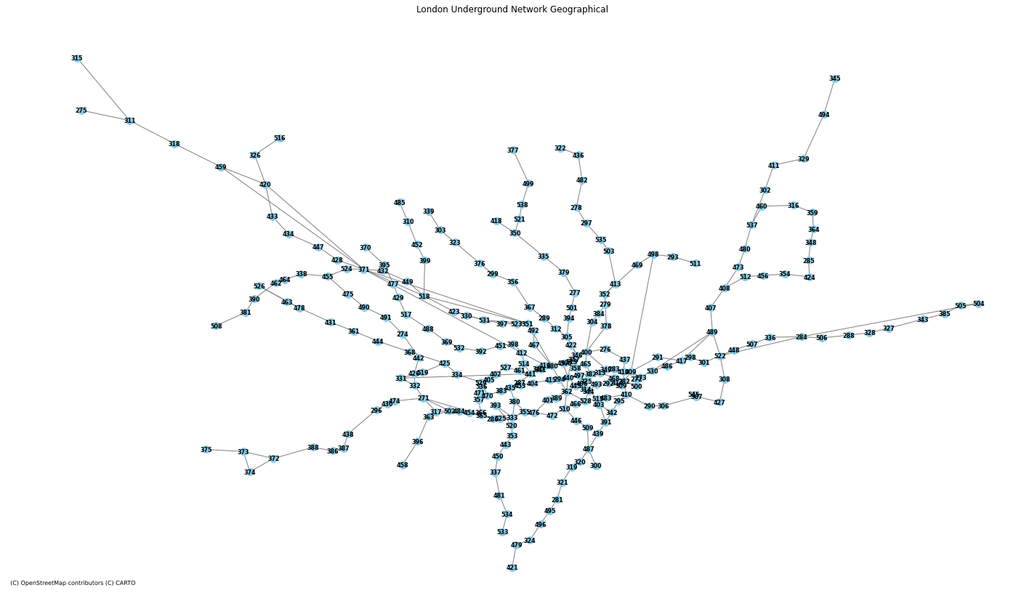

```python
# Plot network with map of the city of London
fig, ax = plt.subplots(figsize=(25, 25))

ctx.add_basemap(ax, crs="EPSG:4326", source=ctx.providers.CartoDB.Positron, zoom=10)

nx.draw(G, pos=pos_geo, with_labels=True, node_size=100, node_color='skyblue',
        font_size=8, font_weight='bold', edge_color='gray', ax=ax)

# Cosmetics and plot
ax.set_xlim(-0.68, 0.29)
ax.set_ylim(51.39, 51.73)
ax.set_aspect(1 / np.cos(np.radians((51.4 + 51.73) / 2)))

plt.title("London Underground Network Geographical")
plt.show()
```

It can be compared the "London Underground Network" to an official map of the City of London Transportation System, here its reinforced the idea of the same arm and central hubs structure, that can be denominated as tree structure, with the metro stations as vertex that are connected throught the metro lines as edges.

[figure not shown]

The "London Underground Network", after the data cleaning, can be represented as an undirected network with 269 nodes (stations) and 324 edges (connections between stations).

```python
# Basic network characteristics
if isinstance(G, nx.DiGraph):
    print("The graph is directed.")
else:
    print("The graph is undirected.")

print("Number of Nodes (Order):", G.number_of_nodes())
print("Number of Edges:", len(G.edges(data=True)))
```

```
The graph is undirected.
Number of Nodes (Order): 269
Number of Edges: 324
```

Then, it is checked if there are any isolated vertices (stations) in the network. It is found the isolated vertex '545' in the London Underground network, which refers to a station that has no connections to any other stations, making it unreachable within the system. In this case, the isolated station is produced as a error of the initial enrichment of with usage data wich left the node isolated. Therefote, the node is deleted to correct for that error.

```python
# Find isolated vertices
print("Isolated Vertices: ",list(nx.isolates(G)))
print(labels["545"])

# Remove node '545' from labels and the graph
labels.pop("545", None)
G.remove_node("545")

print("Isolated Vertices: ",list(nx.isolates(G)))
```

```
Isolated Vertices:  ['545']
Canary Wharf
Isolated Vertices:  []
```

In network analysis, specifically in the context of the "London Underground Network", it's important to identify adjacent vertices (stations) and edges (metro lines). This helps to understand the connections between stations and the metro lines serving them. The following code allows us to find these adjacent vertices, revealing the connections between different metro lines at a given station. Additionally, the adjacent edges provide information about possible line changes that a station can offer, indicating where passengers can switch between different metro lines.

```python
# Get the adjacent vertices
chosen_vertex = '487'

adjacent_vertices = list(G.neighbors(chosen_vertex))
print(f"Adjacent vertices of vertex {chosen_vertex}: {adjacent_vertices}")

adjacent_labels = [labels[vertex] for vertex in adjacent_vertices]
print(f"Adjacent vertices of vertex {labels[chosen_vertex]}: {adjacent_labels}")
```

```
Adjacent vertices of vertex 487: ['300', '320', '439', '509']
Adjacent vertices of vertex Stockwell: ['Brixton', 'Clapham North', 'Oval', 'Vauxhall']
```

```python
# Get the adjacent edges
adjacent_edges = G.edges(chosen_vertex)
print(f"Adjacent edges of vertex {chosen_vertex}: {adjacent_edges}")

for edge in adjacent_edges:
    line_name = G[edge[0]][edge[1]].get('line', 'Unknown Line')
    print(f"Edge: {edge} (Connecting {labels[edge[0]]} and {labels[edge[1]]}) - Metro Line: {line_name}")
```

```
Adjacent edges of vertex 487: [('487', '300'), ('487', '320'), ('487', '439'), ('487', '509')]
Edge: ('487', '300') (Connecting Stockwell and Brixton) - Metro Line: Victoria_line
Edge: ('487', '320') (Connecting Stockwell and Clapham North) - Metro Line: Northern_line
Edge: ('487', '439') (Connecting Stockwell and Oval) - Metro Line: Northern_line
Edge: ('487', '509') (Connecting Stockwell and Vauxhall) - Metro Line: Victoria_line
```

The presence of self-loops in the network was examined, and it was determined that the system does not contain any self-loops. This finding is consistent with the design of most metro systems, where a station typically does not have a direct connection to itself via a metro line. Self-loops are generally avoided in urban transit networks for practical reasons, as they would not contribute to effective transportation or improve connectivity.

```python
# Find self loops
self_loops = [edge for edge in G.edges() if edge[0] == edge[1]]

if self_loops:
    print(f"The graph has {len(self_loops)} self-loop(s):")
    for loop in self_loops:
        print(loop)
else:
    print("The graph does not have any self-loops.")
```

```
The graph does not have any self-loops.
```

```python
# # Find Multi Edges
if isinstance(G, nx.MultiGraph) or isinstance(G, nx.MultiDiGraph):
    multi_edges = [edge for edge in G.edges()]

    if multi_edges:
        print(f"The graph has multi-edges between the following nodes:")
        for edge in multi_edges:
            print(edge)
    else:
        print("The graph does not have any multi-edges.")
else:
    print("The graph is not a MultiGraph or MultiDiGraph, so multi-edges are not allowed.")
```

```
The graph is not a MultiGraph or MultiDiGraph, so multi-edges are not allowed.
```

#### Subnetworks

After getting the "London Underground Network" plot, the exploration of subnetworks and components is performed. From the official transportation map shown above, it can further be derived some of the main subnetworks corresponding to individual metro, light rail or regional train lines.

It is identified the following components 11 Tube Lines + other Lines in "London Underground Network":

- **Bakerloo**: 25 stations
- **Central**: 49 stations
- **Circle**: 35 stations
- **District**: 60 stations
- **Hammersmith & City**: 29 stations
- **Jubilee**: 27 stations
- **Metropolitan**: 34 stations
- **Northern**: 52 stations
- **Piccadilly**: 53 stations
- **Victoria**: 16 stations
- **Waterloo & City**: 2 stations
- +Light Rail, Regional Lines etc

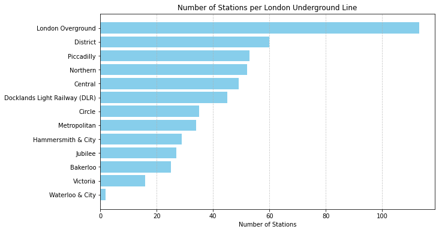

```python
import matplotlib.pyplot as plt

# Generate Data: London Underground lines and their respective number of stations
lines = [
    "Waterloo & City", "Victoria", "Jubilee", "Bakerloo", "Hammersmith & City",
    "Metropolitan", "Circle", "Northern", "Piccadilly", "Central", "District",
    "Docklands Light Railway (DLR)", "London Overground"
]
stations = [2, 16, 27, 25, 29, 34, 35, 52, 53, 49, 60, 45, 113]

# Plot
lines_stations = sorted(zip(stations, lines))
stations_sorted, lines_sorted = zip(*lines_stations)

plt.figure(figsize=(10, 6))
plt.barh(lines_sorted, stations_sorted, color='skyblue')
plt.xlabel('Number of Stations')
plt.title('Number of Stations per London Underground Line')
plt.grid(axis='x', linestyle='--', alpha=0.7)
plt.show()
```

Aditionally, an interesting metro line is Circle Line, as its name refers, it is actually a circle, making the form of a closed walk in a part of the subgraph,an its location goes through the center of the city. In the following plot it is visualy represented.

```
Order of the Circle Line (number of stations): 35
```

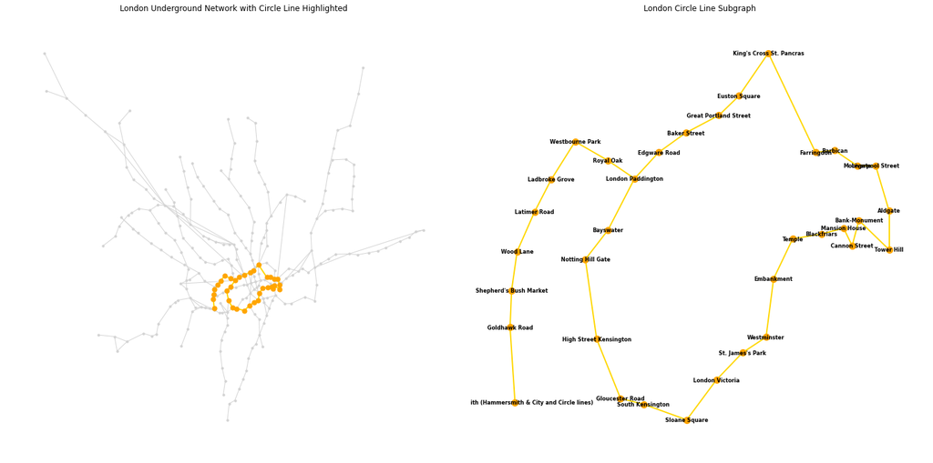

```python
# Define the Circle Line stations
circle_line_stations = [
    "Hammersmith (Hammersmith & City and Circle lines)", "Goldhawk Road",
    "Shepherd's Bush Market", "Wood Lane", "Latimer Road", "Ladbroke Grove",
    "Westbourne Park", "Royal Oak", "London Paddington", "Edgware Road",
    "Baker Street", "Great Portland Street", "Euston Square",
    "King's Cross St. Pancras", "Farringdon", "Barbican", "Moorgate",
    "Liverpool Street", "Aldgate", "Tower Hill", "Bank-Monument",
    "Cannon Street", "Mansion House", "Blackfriars", "Temple", "Embankment",
    "Westminster", "St. James's Park", "London Victoria", "Sloane Square",
    "South Kensington", "Gloucester Road", "High Street Kensington",
    "Notting Hill Gate", "Bayswater"
]

# Plot Circle Line in Network
circle_line_station_ids = [node for node, name in labels.items() if name in circle_line_stations]
circle_line_edges = [(u, v) for u, v in G.edges() if u in circle_line_station_ids and v in circle_line_station_ids]
circle_line_edges = [edge for edge in circle_line_edges if edge not in [('282', '409'), ('282', '419')]]  # Remove incorrect edges
circle_line_nodes = set(circle_line_station_ids)


fig, axes = plt.subplots(1, 2, figsize=(20, 10))
nx.draw(
    G,
    pos=pos_geo,
    with_labels=False,
    node_size=10,
    node_color='lightgray',
    edge_color='lightgray',
    ax=axes[0]
)
nx.draw_networkx_edges(
    G,
    pos=pos_geo,
    edgelist=circle_line_edges,
    edge_color='gold',
    width=2,
    ax=axes[0]
)
nx.draw_networkx_nodes(
    G,
    pos=pos_geo,
    nodelist=circle_line_nodes,
    node_color='orange',
    node_size=50,
    ax=axes[0]
)

axes[0].set_title("London Underground Network with Circle Line Highlighted")


# Plot subgraph
circle_line_subgraph = G.subgraph(circle_line_nodes)

# Plot the Circle Line subgraph
nx.draw(
    circle_line_subgraph,
    pos=pos_geo,
    with_labels=True,
    labels={node: labels[node] for node in circle_line_nodes},
    edgelist=circle_line_edges,
    node_size=100,
    node_color='orange',
    font_size=8,
    font_weight='bold',
    edge_color='gold',
    width=2,
    ax=axes[1]
)
axes[1].set_title("London Circle Line Subgraph")


# Calculate the order (number of nodes) and size (number of edges) of the Circle Line
circle_line_order = len(circle_line_nodes)
circle_line_size = len(circle_line_edges)

print(f"Order of the Circle Line (number of stations): {circle_line_order}")

# Adjust layout
plt.tight_layout()
plt.show()
```

#### Number of components of the network

As mentioned before, the network is undirected, therefore the number of components in the "London Underground Network" reveals that there is only one connected component, indicating that all stations are part of a single, cohesive network. This suggests that the metro system is designed to ensure complete connectivity, with no isolated or disconnected stations. This is ensuring that every station can be reached from any other station, either directly or via transfer.

The fact that there is a single connected component also reflects the network's design efficiency, and confirms that the network is a weakly connected graph, you can travel between any two vertices by following some set of edges. This means that commuters can travel seamlessly between any two points within the system without encountering unreachable stations. This networks helps in the flexibility of route planning, including multiple tranfer points in more central lines to be able to reach any part of the city that has a metro line.

Additionally, it will enfasises the importance of stations located in the center of the city that can have more traffic, and can serve as critical nodes in maintaining overall network cohesion.

```python
#Find connected components
connected_components = list(nx.connected_components(G))
num_components = len(connected_components)

print(f"Number of connected components: {num_components}")
```

```
Number of connected components: 1
```

### Diameter

**Diameter without weights**

The longest shortest path between any two stations in the London Underground network spans 35 vertices (stations). It will indicates, the furthest distance between any two stations, based on the shortest possible route, requires traveling through 35 stations across the city. For the "London Underground Network" those stations (nodes) are going to be "Epping" and "Harrow & Wealdstone"

```python
# Find Diameter of Code
if nx.is_connected(G):
    diameter = nx.diameter(G)
    print(f"The diameter of the connected graph is: {diameter}")
else:
    print("The graph is disconnected.")

# Find the pair of nodes that defines the diameter
if nx.is_connected(G):
    diameter_path = nx.diameter(G)
    longest_shortest_path = nx.periphery(G)

    diameter_nodes = longest_shortest_path[:2]
    print(f"The diameter lies between stations: {diameter_nodes[0]} and {diameter_nodes[1]}")
```

```
The diameter of the connected graph is: 35
The diameter lies between stations: 345 and 370
```

The following code provides both the sequence of station names along the shortest route and the total distance of travel between the two specified stations, making it useful for analyzing travel routes in the London Undergroung metro system network.

The code calculates the total distance (sum of the weights) of the shortest path using Dijkstra's algorithm, which reflects the total travel distance between the two stations. If no path exists between the nodes or if a node is not found in the graph, appropriate error messages are displayed.

```python
def find_shortest_path(graph, initial_vertex, final_vertex):

    # Find the shortest path
    path = nx.dijkstra_path(graph, source=initial_vertex, target=final_vertex, weight='dist')
    path_station_names = [graph.nodes[node].get('label', 'No Label') for node in path]
    path_length = len(path) - 1
    path_distance = nx.dijkstra_path_length(graph, source=initial_vertex, target=final_vertex, weight='dist')


    print("Shortest Path (Node IDs):", path)
    print("Shortest Path (Station Names):", path_station_names)
    print("Number of Stations in Path:", path_length)
    print("Total Distance (km):", path_distance)


find_shortest_path(G, '345', '370')
```

```
Shortest Path (Node IDs): ['345', '494', '329', '411', '302', '537', '480', '473', '408', '407', '489', '530', '273', '409', '419', '283', '349', '400', '347', '360', '280', '341', '441', '514', '412', '398', '451', '392', '532', '369', '488', '517', '429', '477', '395', '370']
Shortest Path (Station Names): ['Epping', 'Theydon Bois', 'Debden', 'Loughton', 'Buckhurst Hill', 'Woodford', 'South Woodford', 'Snaresbrook', 'Leytonstone', 'Leyton', 'Stratford', 'Whitechapel', 'Aldgate East', 'Liverpool Street', 'Moorgate', 'Barbican', 'Farringdon', "King's Cross St. Pancras", 'E…
Number of Stations in Path: 35
Total Distance (km): 64.2756406417444
```

```python
def plot_shortest_path(G, start_id, stop_id):

    """
    Plot the shortest path between two nodes in a graph.
    """

    # Calculate shortest path
    try:
        shortest_path = nx.dijkstra_path(G, source=start_id, target=stop_id, weight='dist')
    except nx.NetworkXNoPath:
        print(f"No path exists between {start_id} and {stop_id}.")
        return

    # Extract edges on shortest path
    path_edges = list(zip(shortest_path[:-1], shortest_path[1:]))

    ### Plot
    fig, ax = plt.subplots(figsize=(25, 25))  # More balanced size

    ax.set_xlim(-0.68, 0.29) # london coords
    ax.set_ylim(51.39, 51.73)

    ax.set_aspect(1 / np.cos(np.radians((51.4 + 51.73) / 2)))  # Adjust for London's latitude

    # map and network
    ctx.add_basemap(ax, crs="EPSG:4326", source=ctx.providers.CartoDB.Positron, zoom=10)
    nx.draw(G, pos=pos_geo, with_labels=False, node_size=50, node_color='lightgray',
            edge_color='lightgray', ax=ax)

    # shortest path
    nx.draw_networkx_edges(G, pos=pos_geo, edgelist=path_edges, edge_color='lightblue', width=3, ax=ax)
    nx.draw_networkx_nodes(G, pos=pos_geo, nodelist=shortest_path, node_color='darkblue', node_size=100, ax=ax)

    # start and stop
    nx.draw_networkx_labels(G, pos=pos_geo, labels={start_id: labels[start_id], stop_id: labels[stop_id]}, font_size=12, ax=ax)

    plt.title(f"Shortest Path from {labels[start_id]} to {labels[stop_id]}")
    plt.show()





def plot_highlighted_stations(G, pos_geo, station_nodes, labels):
    """
    plot network with highlighted stations
    """

    # Plot the network
    plt.figure(figsize=(12, 8))
    nx.draw(G, pos=pos_geo, with_labels=False, node_size=10, node_color='lightgray', edge_color='lightgray')
    nx.draw_networkx_nodes(G, pos=pos_geo, nodelist=station_nodes, node_color='purple', node_size=100, label='Highlighted Stations')

    # Add labels
    nx.draw_networkx_labels(G, pos=pos_geo, labels={node: labels[node] for node in station_nodes}, font_size=8)

    # cosmetics
    plt.legend(scatterpoints=1, loc='upper left', fontsize=10)
    plt.title("London Tube Network with Highlighted Stations")
    plt.show()
```

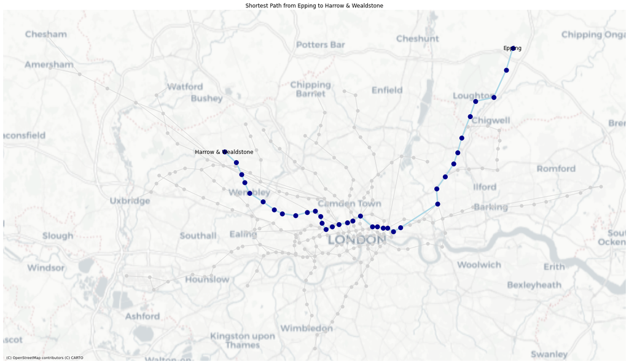

```python
plot_shortest_path(G, '345', '370')
```

**Diameter with weights**

In the "London Underground Network", the weighted diameter of the graph can also be calculated. This metric represents the longest shortest path between any two nodes, taking into account the weights assigned to the edges, such as physical distance or travel time.

In this case, using inverse distance as the edge weight (shorter physical distances are given higher weights), the weighted diameter of the graph is 23.68. This is a significant reduction compared to the unweighted diameter, where all edges are treated equally. The use of inverse distance highlights the importance of edge weights in understanding the true structure and efficiency of the network.

```python
# Calculate the shortest paths (weighted)
shortest_path_lengths = dict(nx.all_pairs_dijkstra_path_length(G, weight=lambda u, v, d: 1 / d['dist'] if 'dist' in d else float('inf')))

# Find the diameter
weighted_diameter = max(max(lengths.values()) for lengths in shortest_path_lengths.values())

print(f"The diameter of the graph with weights (inverse distance) is: {weighted_diameter}")
for source, lengths in shortest_path_lengths.items():
    for target, length in lengths.items():
        if length == weighted_diameter:
            print(f"The two stations corresponding to the weighted diameter are: {source} and {target}")
            break
```

```
The diameter of the graph with weights (inverse distance) is: 23.68140839665368
The two stations corresponding to the weighted diameter are: 421 and 366
```

```python
find_shortest_path(G, '421', '366')
```

```
Shortest Path (Node IDs): ['421', '479', '324', '496', '495', '281', '321', '319', '320', '487', '509', '446', '510', '362', '294', '280', '341', '441', '461', '527', '402', '405', '536', '471', '357', '366']
Shortest Path (Station Names): ['Morden', 'South Wimbledon', 'Colliers Wood', 'Tooting Broadway', 'Tooting Bec', 'Balham', 'Clapham South', 'Clapham Common', 'Clapham North', 'Stockwell', 'Vauxhall', 'Pimlico', 'London Victoria', 'Green Park', 'Bond Street', 'Baker Street', 'Edgware Road', 'London P…
Number of Stations in Path: 25
Total Distance (km): 29.120318862949997
```

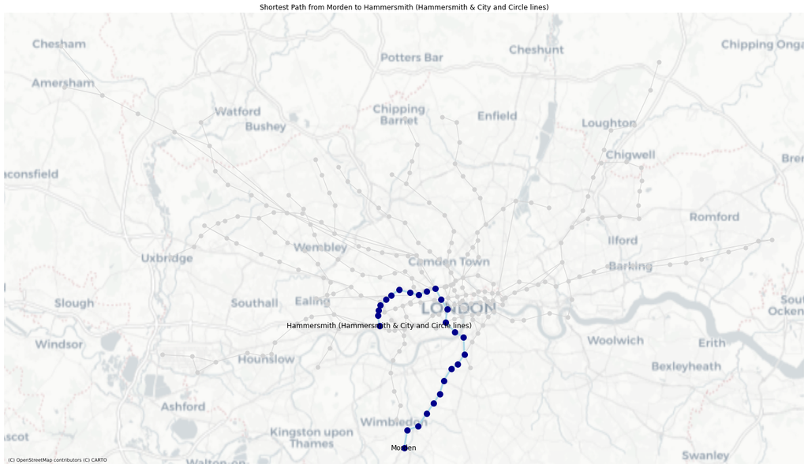

```python
plot_shortest_path(G, '421', '366')
```

#### Adjecency Matrix

The analysis of the "London Underground Network" throught the Adjancency Matrix it is shown a low average 0.009 per node, which is a signal of low connectivity in the network or the metro system. This results goes through the direct behaviour and design of transportation networks, as the statios are mostly connected to few neighbors (in many cases just two , corresponding to the next and previos station) in the same metro line, rather to every other station in the system. This transportation network ephasizes the efficiency through the metro system, therefore having high connectivity can lead to an impractical metro design, as the metro system works as the arms connecting to the center of the city where passengers can create a combination of connections and tranfers to reach their desired station in the city. Therefore, a low connectivity in the "London underground Network" is a characteristic of an optimized network according to the urban mobility.

```python
import scipy.io

# Generate the adjacency matrix
adj_matrix = nx.adjacency_matrix(G)
adj_matrix_dense = adj_matrix.todense()

# Calculate the mean
mean_adj_matrix = np.mean(adj_matrix_dense)
print(f"Mean of the adjacency matrix: {mean_adj_matrix}")
```

```
Mean of the adjacency matrix: 0.009022053909556694
```

## Network Visualization

With the properties of the "London Underground Network" defined and a general understanding of the node (stations) and Edge (metro lines) attributes, it is applied some visualization tecniques to gain further understanding of the network

#### Energy based Visualizations

Following graphs layouts are based on energy functions, where the algorithm simulates physical forces to determine node positions. The layout process aims to minimize a global energy function.

The main focus in the "London Underground Network" with the corresponding energy layouts is to reveal clusters, central hubs or important vertex in a clearer visually way.

#### Davidson and Harel layout:

The Davidson and Harel layout will aim for a result with a minimal edge crossing. It is plotted the layouts with the stations names and node number for easier visualization.

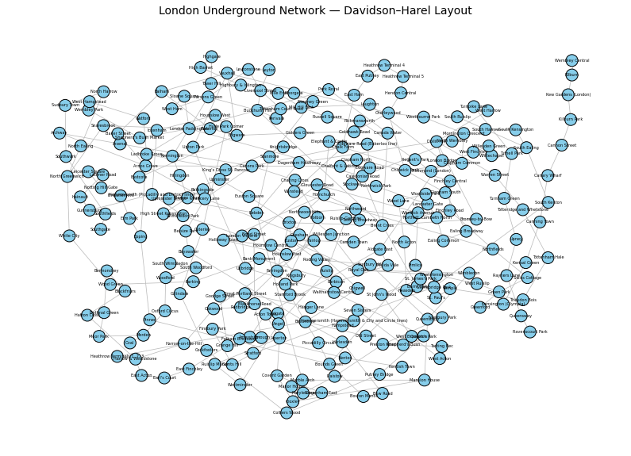

```python
ig.set_random_number_generator(random.Random(1))

# Prep Graph
edges_i = list(G.edges())
ig_graph = ig.Graph.TupleList(edges_i, directed=False)

if 'label' in list(G.nodes(data=True))[0][1]:
    station_labels = [data['label'] for _, data in G.nodes(data=True)]
else:
    station_labels = [str(n) for n in G.nodes()]

ig_graph.vs["name"] = station_labels

#Compute Davidson–Harel layout
layout_dh = ig_graph.layout("dh")

#Plot the graph
fig, ax = plt.subplots(figsize=(14, 10))
ig.plot(
    ig_graph,
    layout=layout_dh,
    target=ax,
    vertex_label=ig_graph.vs["name"],
    vertex_size=15,
    vertex_color="skyblue",
    edge_color="gray",
    edge_width=0.8,
    vertex_label_size=5,
)
plt.title("London Underground Network — Davidson–Harel Layout", fontsize=14)
plt.axis('off')
plt.show()
```

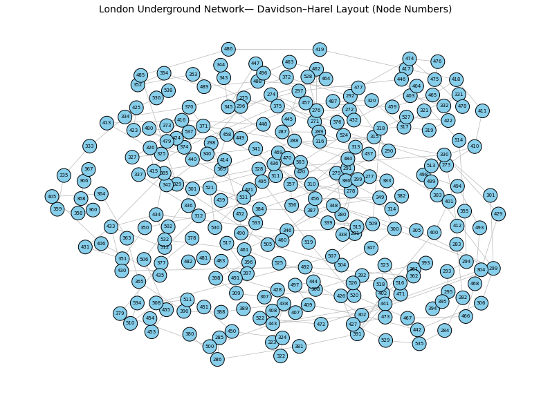

```python
# Prep
node_ids = list(G.nodes())
ig_graph.vs["name"] = [str(n) for n in node_ids]  # Cast to str for labeling

# Compute Davidson–Harel
layout_dh = ig_graph.layout("dh")

# Plot
fig, ax = plt.subplots(figsize=(14, 10))
ig.plot(
    ig_graph,
    layout=layout_dh,
    target=ax,
    vertex_label=ig_graph.vs["name"],
    vertex_size=20,
    vertex_color="skyblue",
    edge_color="gray",
    edge_width=0.8,
    vertex_label_size=7,
)
plt.title("London Underground Network— Davidson–Harel Layout (Node Numbers)", fontsize=14)
plt.axis('off')
plt.show()
```

The Davidson and Harel layout applied to the "London Underground Network" produces a circular, evenly distributed visualization where no particular emphasis is placed on important stations or clusters. All nodes (stations) are positioned based on force-directed principles, without automatically highlighting central hubs or high-connectivity areas. As a result, key stations with higher degrees are not visually distinguished. To address this, we will manually highlight the stations with the highest degrees to better illustrate their significance within the network.

Let's called again the top 5 nodes with the highest unweighted degrees.

```python
#  top 5 nodes with the highest degrees
degrees = dict(G.degree())  # {node: degree}
degree_sequence = [degree for node, degree in degrees.items()]
sorted_nodes_by_degree = sorted(degrees.items(), key=lambda x: x[1], reverse=True)[:5]

# top 5 nodes with degrees and labels
print("\nTop 5 nodes with the highest degrees:")
for node, degree in sorted_nodes_by_degree:
    label = G.nodes[node].get('label', 'No Label')
    print(f"Node: {node}, Label: {label}, Degree: {degree}")
```

```
Top 5 nodes with the highest degrees:
Node: 371, Label: Harrow-on-the-Hill, Degree: 8
Node: 280, Label: Baker Street, Degree: 7
Node: 400, Label: King's Cross St. Pancras, Degree: 7
Node: 282, Label: Bank-Monument, Degree: 6
Node: 333, Label: Earl's Court, Degree: 6
```

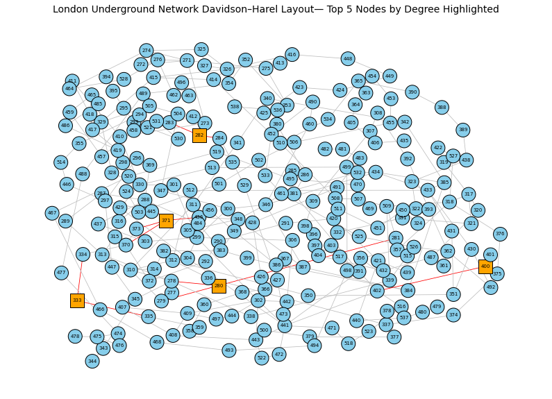

```python
highlight_labels =  ['371','280','400','282','333']
vertex_colors = ['orange' if name in highlight_labels else 'skyblue' for name in ig_graph.vs["name"]]
vertex_shapes = ['square' if name in highlight_labels else 'circle' for name in ig_graph.vs["name"]]

# Highlight edges connected to top nodes
edge_colors = []
for edge in ig_graph.es:
    src = ig_graph.vs[edge.source]["name"]
    tgt = ig_graph.vs[edge.target]["name"]
    if src in highlight_labels or tgt in highlight_labels:
        edge_colors.append('red')
    else:
        edge_colors.append('gray')

#  Layout and plot
layout_dh = ig_graph.layout("dh")

fig, ax = plt.subplots(figsize=(14, 10))
ig.plot(
    ig_graph,
    layout=layout_dh,
    target=ax,
    vertex_label=ig_graph.vs["name"],
    vertex_size=20,
    vertex_color=vertex_colors,
    vertex_shape=vertex_shapes,
    edge_color=edge_colors,
    edge_width=0.8,
    vertex_label_size=7,
)
plt.title("London Underground Network Davidson–Harel Layout— Top 5 Nodes by Degree Highlighted", fontsize=14)
plt.axis('off')
plt.show()
```

As mentioned, these top 5 stations were not easily identifiable thought visual inspection, therefore the Davidson-Harel layout is not well-suited to get a visual representation of the "London Underground Network". The algorithm layouts in overlapping nodes or distorted relationships, making it difficult to recognize key stations and the overall network structure.

##### Kamada and Kawai layout:

The Kamada and Kawait layout (another type of energy-based graph visualization method) aims to position nodes so their shortest path distances are preserved as accurately as possible, related nodes are placed closer together and overall structure is more readable.

The Kamada and Kawai layout produces a visualization that closely resembles the actual geographic structure of the London Underground, though not an exact match. By approximating ideal distances between all pairs of stations based on their shortest path lengths, the layout naturally forms a tree-like structure, with several "arms" of the network radiating outward from the central hub stations. This helps to visually emphasize how the main lines converge in central London, reflecting the real-world connectivity and flow of the metro system.

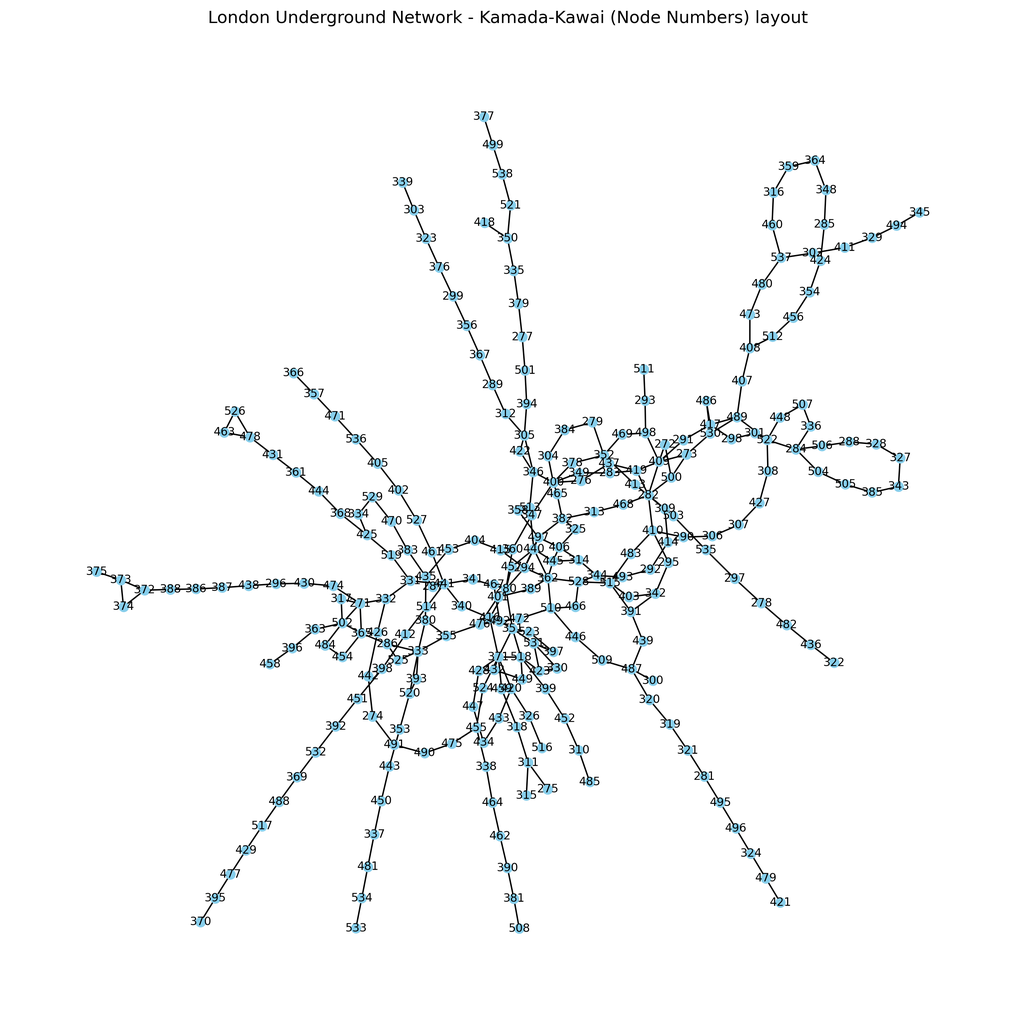

```python
# Define layouts
layouts = {
    "London Underground Network - Kamada-Kawai (Node Numbers)": nx.kamada_kawai_layout,
}

plt.figure(figsize=(30, 20),dpi = 300)
for i, (name, layout_func) in enumerate(layouts.items(), 1):
    pos = layout_func(G)
    plt.subplot(2, 3, i)
    nx.draw(G, pos, with_labels=True, node_size=40, node_color='skyblue', font_size=8)
    plt.title(f"{name} layout")

plt.tight_layout()
plt.show()
```

The following code highlights stations with more than three connections (a degree greater than 3) in the unweighted graph of the "London Underground Network". As seen in the resulting layout, these high-degree stations are predominantly located near the center of the network-city. This distribution aligns with the real-world structure of London, where central stations act as major interchange hubs, facilitating connectivity between multiple lines. These central nodes play a crucial role in ensuring efficient passenger flow across the broader metro system.

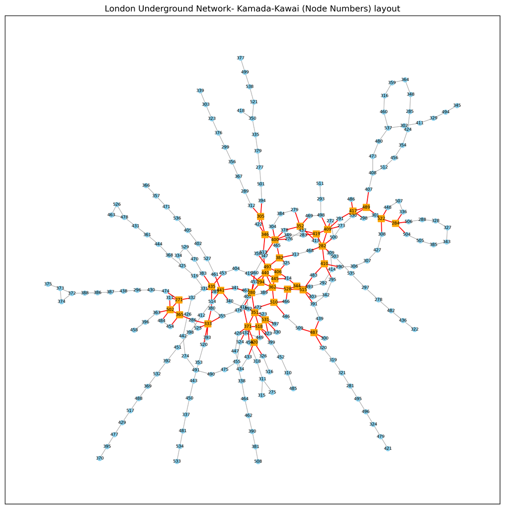

```python
### Kamda Kawai
# Define layouts
layouts = {
    "London Underground Network- Kamada-Kawai (Node Numbers)": nx.kamada_kawai_layout,
}

# Identify nodes with degree > 3
high_degree_nodes = [n for n in G.nodes if G.degree(n) > 3]
low_degree_nodes = [n for n in G.nodes if G.degree(n) <= 3]

# Identify edges that connect to high-degree nodes
high_degree_edges = [e for e in G.edges if e[0] in high_degree_nodes or e[1] in high_degree_nodes]
low_degree_edges = list(set(G.edges) - set(high_degree_edges))

plt.figure(figsize=(30, 20),dpi = 300)
for i, (name, layout_func) in enumerate(layouts.items(), 1):
    pos = layout_func(G)
    plt.subplot(2, 3, i)

    # low-degree nodes
    nx.draw_networkx_nodes(G, pos,
                           nodelist=low_degree_nodes,
                           node_color='skyblue',
                           node_shape='o',
                           node_size=40)

    # high-degree nodes with a different shape and color
    nx.draw_networkx_nodes(G, pos,
                           nodelist=high_degree_nodes,
                           node_color='orange',
                           node_shape='s',  # square
                           node_size=80)

    # edges not connected to high-degree nodes
    nx.draw_networkx_edges(G, pos,
                           edgelist=low_degree_edges,
                           edge_color='gray',
                           width=0.5)

    # edges connected to high-degree nodes
    nx.draw_networkx_edges(G, pos,
                           edgelist=high_degree_edges,
                           edge_color='red',
                           width=1.2)

    nx.draw_networkx_labels(G, pos, font_size=6)
    plt.title(f"{name} layout")

plt.tight_layout()
plt.show()
```

#### Fruchterman-Reingold

The Fruchterman-Reingol layout, treats nodes like charged particles that repel each other, while edges act like springs that pull connected nodes together, resulting in a layout where related nodes are placed closer together and the overall structure is more visually intuitive.

When applied to the London Underground network, the Fruchterman-Reingold layout reveals a general structure where some "arms" of the network, representing individual metro lines, extend outward with stations connected in a linear fashion. However, the central area appears denser and more tangled, lacking clear clustering or emphasis on specific stations. While the layout does not explicitly highlight important hubs, the visual density at the center suggests the presence of key interchange stations where multiple lines converge. This reflects the real-world role of central London stations as critical connection points within the network.

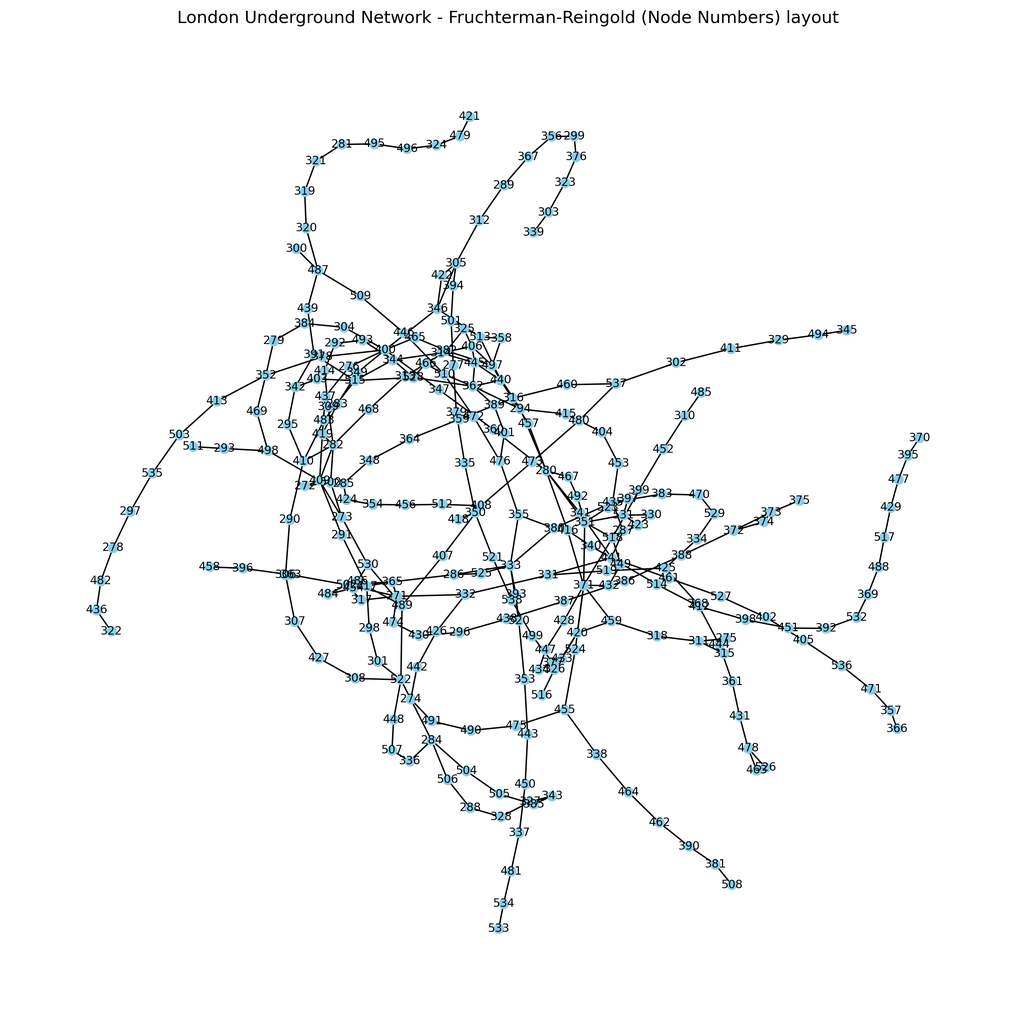

```python
# Define layouts
layouts = {
    "London Underground Network - Fruchterman-Reingold (Node Numbers)":nx.spring_layout,
}

plt.figure(figsize=(30, 20),dpi = 300)
for i, (name, layout_func) in enumerate(layouts.items(), 1):
    pos = layout_func(G, seed = 1)
    plt.subplot(2, 3, i)
    nx.draw(G, pos, with_labels=True, node_size=40, node_color='skyblue', font_size=8)
    plt.title(f"{name} layout")

plt.tight_layout()
plt.show()
```

The following code applies the Fruchterman-Reingold force-directed algorithm to visualize the "London Underground Network". It highlights stations (nodes) whose weighted degree calculated as the sum of the inverse distances to neighboring stations exceeds a value of 4. Stations located in central London, where multiple lines intersect and distances between stations are shorter, are more likely to meet this threshold. As expected, several central nodes are visually emphasized in the layout. Notably, station 471, which appears along one of the network's outer branches, is also highlighted. This prompts a closer investigation into its structure and connections to understand why it stands out in terms of weighted connectivity.

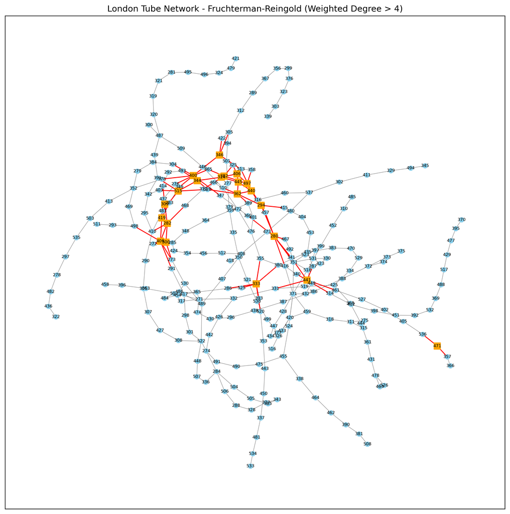

```python
# Calculate the weighted degree for each node using inverse of the distance
def weighted_degree(graph):
    weighted_degrees = {}
    for node in graph.nodes:
        w_degree = 0
        for neighbor in graph.neighbors(node):
            weight = graph[node][neighbor].get('dist', 1)  # Default to 1 if no 'dist'
            if weight > 0:
                w_degree += 1 / weight
        weighted_degrees[node] = w_degree
    return weighted_degrees

# Classify nodes based on weighted degree
weighted_degrees = weighted_degree(G)
threshold = 4
high_degree_nodes = [n for n, d in weighted_degrees.items() if d > threshold]
low_degree_nodes = [n for n in G.nodes if n not in high_degree_nodes]

# Classify edges connected to high-degree nodes
high_degree_edges = [e for e in G.edges if e[0] in high_degree_nodes or e[1] in high_degree_nodes]
low_degree_edges = list(set(G.edges) - set(high_degree_edges))

# Plot
layouts = {
    "London Tube Network - Fruchterman-Reingold (Weighted Degree > 4)": nx.spring_layout,
}

plt.figure(figsize=(30, 20),dpi = 300)
for i, (name, layout_func) in enumerate(layouts.items(), 1):
    pos = layout_func(G, seed = 1)
    plt.subplot(2, 3, i)

    # low-degree nodes
    nx.draw_networkx_nodes(G, pos,
                           nodelist=low_degree_nodes,
                           node_color='skyblue',
                           node_size=40,
                           node_shape='o')

    # high-degree nodes
    nx.draw_networkx_nodes(G, pos,
                           nodelist=high_degree_nodes,
                           node_color='orange',
                           node_size=80,
                           node_shape='s')

    # edges not connected to high-degree nodes
    nx.draw_networkx_edges(G, pos,
                           edgelist=low_degree_edges,
                           edge_color='gray',
                           width=0.5)

    # edges connected to high-degree nodes
    nx.draw_networkx_edges(G, pos,
                           edgelist=high_degree_edges,
                           edge_color='red',
                           width=1.2)

    # labels
    nx.draw_networkx_labels(G, pos, font_size=6)

    plt.title(f"{name}")

plt.tight_layout()
plt.show()
```

Upon further analysis of node 471, which corresponds to Shepherd's Bush Market station, we observe that its degree is 2. This means the station has 2 edges connecting it to other stations in the network. However, the weighted degree of the station is significantly higher, at 4.315. The weighted degree is calculated based on the inverse of the distance to neighboring stations, which is used to measure the strength of its connections. Specifically, the inverse of the distance (smaller distances contribute more heavily) reflects how "close" a node is to its neighbors. Lower distances between stations lead to higher weighted degrees, meaning that Shepherd's Bush Market is relatively close to its connected stations compared to other nodes with higher distances, making it a more strongly connected node in terms of proximity.

This closer relationship is further emphasized in the plot of "London Tube Network - Fruchterman-Reingold (Weighted Degree > 4)". In this plot, stations with weighted degrees greater than 4 are highlighted, despite Shepherd's Bush Market station having only 2 direct connections (degree without weights), its strong weighted degree indicates that those connections are particularly close, contributing to its prominence in the network.

```python
# Get degree
node = '471'
degree_ = G.degree[node]
print(f"Degree of node {node}:", degree_)

label_ = G.nodes[node].get('label', 'No label found')
print(f"Label of node {node}:", label_)

# Retrieve weighted degree of node 471
weighted_degree_ = weighted_degrees.get(node, "Node not found")
print(f"Weighted degree of node {node}:", weighted_degree_)
```

```
Degree of node 471: 2
Label of node 471: Shepherd's Bush Market
Weighted degree of node 471: 4.315239636255769
```

When using energy-based layouts, it becomes evident that the Kamada-Kawai algorithm provides a visualization that goes closely to the real spatial structure of the "London Underground Network", especially when plotted using node coordinates. However, overall, energy-based visualizations do not offer a better understanding of the network than the simple geographical layout initially used. Since the network is already well-defined and each station has accurate geographic coordinates, these abstract layouts add little new insight into its structure. But, they can be useful for offering a quick visual indication of node centrality, depending on the specific energy function applied. It may be valuable to revisit these plots after calculating centrality measures, as the layouts might better highlight structural roles and relationships within the network under that context.

#### Multi Dimensional Scaling (MDS)

Multi Dimensional Scaling is a distance matrix based dimension reduction technique. To apply it to the "London Underground Network", first it is generate the distance matrix by solving shortest path issues for each pair of nodes.

```python
# Generate distance Matrix (Compute the shortest path distances between all pairs of nodes)
distance_matrix = dict(nx.all_pairs_dijkstra_path_length(G, weight='dist'))

# Convert to df
distance_df = pd.DataFrame.from_dict(distance_matrix, orient='index')
distance_df = distance_df.reindex(index=G.nodes(), columns=G.nodes())
```

With the distance matrix set up, the MDS methods is imported and then is applied them to distance matrix. The resulting visualization has a similar tree like structure, with most nodes close distances in the network also remain close in the MDS Visualization. However, it is also identified some clearly distorted node, like node 526, with no clear explanation on why they appear to be so distorted. In general the first MDS Coordinate appears to have been in some ways the longitude but flipped (e.g. stations previously to the right now more to the left and vice versa), while the second MDS coordinate is not very insightful, with some stations previously in the North remaining, while others are moved to the "south".

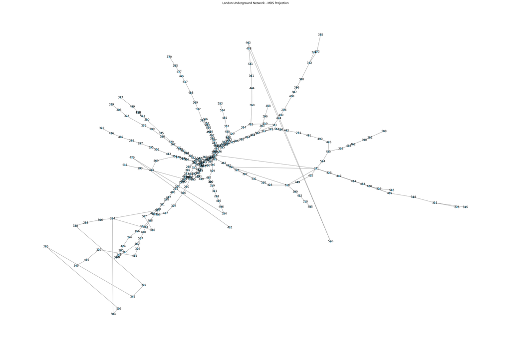

```python
from sklearn.manifold import MDS

# Run MDS
distance_array = distance_df.values
mds = MDS(n_components=2, dissimilarity='precomputed', random_state=42)
mds_coordinates = mds.fit_transform(distance_array)
mds_df = pd.DataFrame(mds_coordinates, columns=['MDS1', 'MDS2'], index=distance_df.index)


# Plot MDS (first two components)
plt.figure(figsize=(30, 20))
mds_positions = {str(node): (row['MDS1'], row['MDS2']) for node, row in mds_df.iterrows()}
nx.draw(
    G,
    pos=mds_positions,
    with_labels=True,
    node_size=50,
    node_color='skyblue',
    edge_color='gray'
)
plt.title("London Underground Network - MDS Projection")
plt.show()
```

In some way, the result can be seen as an attempt to reconstruct the attributes longitude and latitude via first and second MDS coordinate from the nodes pairwise distances. As however the precise geographical positions of the nodes are known already through their longitude and latitude, MDS appears not to be able to add significant insights.

### Centrality Measures

The following section contains the analysis into the centrality of nodes and edges.

**Degree distribution**

**Degrees without weights**

The average degree is calculated to be 2.42, which aligns with expectations. As most stations in the metro network are typically connected by a single line, with each station having two adjacent connections: one to the previous station and one to the next. Such a structure is common in metro systems, where the majority of stations are part of a linear sequence of stops

```python
# Calculate the average degree of the graph
average_degree = sum(dict(G.degree()).values()) / len(G.nodes())

print(f"Average degree of the network: {average_degree:.2f}")
```

```
Average degree of the network: 2.42
```

In general, we observe that that stations have a degree of two, being a pass through station on one of the lines. Then, there is a few nodes having degree 1 corresponding to end stops of lines and other stations with degree 3+ connecting two or more lines.

The top 5 nodes with the highest degrees in the network are Harrow-on-the-Hill, Baker Street, Bank-Monument, King's Cross St. Pancras, and Earl's court. Harrow-on-the-Hill stands out with the highest degree of 8, indicating it has the most connections in the network. The other two stations—Baker Street and King's Cross St. Pancras have a degree of 7, showing they are all well-connected with a similar number of edges. Following the other two reamingn stations Bank-monument and Earl's Court have a degree of 6, in general, these stations are central hubs in the network, with varying but significant levels of connectivity. These stations are all above the average degree of the network, which is 2.42. Their higher degrees suggest they are significantly more connected than the average station, reflecting their importance in facilitating movement and providing multiple transport links. Some initial assumptions about their locations and roles in London transportation help provide context, a more detailed analysis would involve evaluating commuter traffic, station facilities, and transport links to further understand their importance within the network.

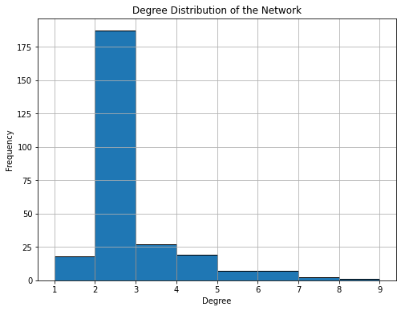

```
Top 5 nodes with the highest degrees:
Node: 371, Label: Harrow-on-the-Hill, Degree: 8
Node: 280, Label: Baker Street, Degree: 7
Node: 400, Label: King's Cross St. Pancras, Degree: 7
Node: 282, Label: Bank-Monument, Degree: 6
Node: 333, Label: Earl's Court, Degree: 6
```

```python
# Degree distribution (histogram)
degrees = dict(G.degree())

degree_sequence = [degree for node, degree in degrees.items()]

plt.figure(figsize=(8, 6))
plt.hist(degree_sequence, bins=range(min(degree_sequence), max(degree_sequence) + 2), edgecolor='black')
plt.title('Degree Distribution of the Network')
plt.xlabel('Degree')
plt.ylabel('Frequency')
plt.grid(True)
plt.show()

# top 5 nodes with highest degrees
sorted_nodes_by_degree = sorted(degrees.items(), key=lambda x: x[1], reverse=True)[:5]

# Print top 5 nodes with their degrees and labels
print("\nTop 5 nodes with the highest degrees:")
for node, degree in sorted_nodes_by_degree:
    label = G.nodes[node].get('label', 'No Label')
    print(f"Node: {node}, Label: {label}, Degree: {degree}")
```

Overall, these stations indeed are more central to the network in a connectivity sense, as they represent the hubs at which passengers of the metro system can switch between lines and will thus see a substantial percentage of all passangers moving through those hubs.

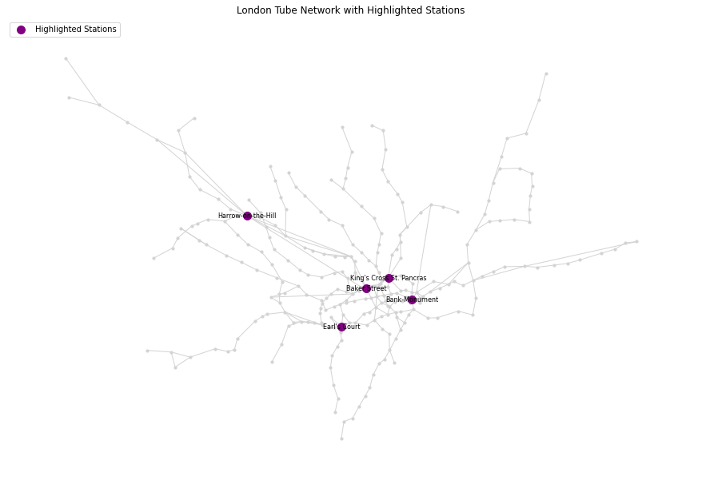

```python
# top 5 nodes by degree
top_5_degree_nodes = [node for node, degree in sorted_nodes_by_degree]
plot_highlighted_stations(G, pos_geo, top_5_degree_nodes, labels)
```

**Degrees with weights**

The network's degree distribution reveals an average weighted degree of 1.77, indicating that, on average, each station has a relatively modest number of strong connections when considering the inverse of the distance as the weight. The arcs weighted by their inverse distance can in this case be interpreted as the geographical closeness of the station to other stations in the network, as the inverse of a small distance yields a large weight. Then a large sum of these weights shows that metro stations have either a few stations that are very close to it or many stations connected to it but that might be a bit further away.

Notably, the top 5 stations with the highest weighted degrees, which are Bank-Monument (7.79), Leicester Square (7.18), Embankment (6.36), Charing Cross (5.92), and Waterloo (5.77), are all located in central and highly trafficked areas of the metro system. These stations exhibit significantly higher connectivity strength, suggesting they serve as major hubs where multiple metro lines converge. Their elevated weighted degrees reflect their crucial roles in the network, as they facilitate efficient transfers and high passenger flow. In the metro system is expected that the central stations are designed to handle high volumes of passengers and connections across various lines.

```
Average weighted degree: 1.77
Top 5 stations with highest weighted degrees:
Station: Bank-Monument (ID: 282), Weighted Degree: 7.79
Station: Leicester Square (ID: 406), Weighted Degree: 7.18
Station: Embankment (ID: 344), Weighted Degree: 6.36
Station: Charing Cross (ID: 314), Weighted Degree: 5.92
Station: Waterloo (ID: 515), Weighted Degree: 5.77
```

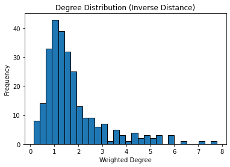

```python
# Weighted degree
def weighted_degree(graph, labels):
    weighted_degrees = {}
    for node in graph.nodes:
        weighted_degree = 0
        for neighbor in graph.neighbors(node):
            #(inverse of distance as weight)
            weight = graph[node][neighbor].get('dist', 1)
            weighted_degree += 1 / weight
        weighted_degrees[node] = weighted_degree
    return weighted_degrees

weighted_degrees = weighted_degree(G, labels)

# average degree
average_degree = sum(weighted_degrees.values()) / len(weighted_degrees)
print(f"Average weighted degree: {average_degree:.2f}")

# top 5 nodes
top_5_stations = sorted(weighted_degrees.items(), key=lambda x: x[1], reverse=True)[:5]
print("Top 5 stations with highest weighted degrees:")
for node, degree in top_5_stations:
    station_name = labels.get(node, "Unknown Station")  # Get the station name using the label dictionary
    print(f"Station: {station_name} (ID: {node}), Weighted Degree: {degree:.2f}")


# Plot
all_degrees = list(weighted_degrees.values())

plt.hist(all_degrees, bins=30, edgecolor='black')
plt.title("Degree Distribution (Inverse Distance)")
plt.xlabel("Weighted Degree")
plt.ylabel("Frequency")
plt.show()
```

```python
print("Top 5 nodes with the highest weighted degrees:")
for node, degree in sorted(weighted_degrees.items(), key=lambda x: x[1], reverse=True)[:5]:
    print(f"Node: {node} ({labels[node]}), Weighted Degree: {degree:.2f}")
```

```
Top 5 nodes with the highest weighted degrees:
Node: 282 (Bank-Monument), Weighted Degree: 7.79
Node: 406 (Leicester Square), Weighted Degree: 7.18
Node: 344 (Embankment), Weighted Degree: 6.36
Node: 314 (Charing Cross), Weighted Degree: 5.92
Node: 515 (Waterloo), Weighted Degree: 5.77
```

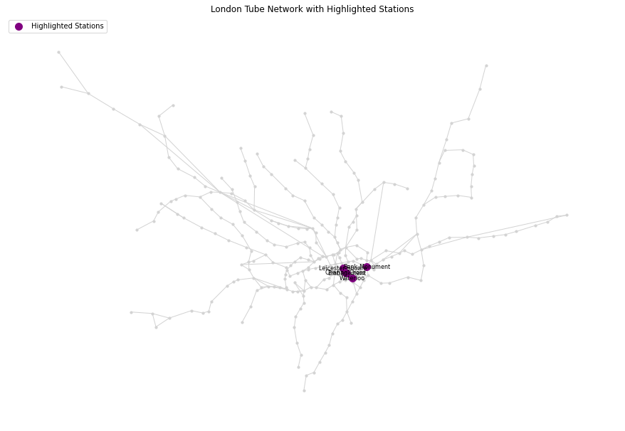

```python
#Get top 5 nodes by degree weighted
top_5_stations_g = sorted(weighted_degrees.items(), key=lambda x: x[1], reverse=True)[:5]
top_5_degree_nodes = [node for node, degree in top_5_stations_g]

plot_highlighted_stations(G, pos_geo, top_5_degree_nodes, labels)
```

**Closeness Centrality**

The closeness centrality, being 1 over the sum of (shortest) distances of the one node to every other node in the system, gives a metric that defines centrality in the sense of closeness to all other nodes in the system. The top stations with that metric are very close to each other and in a sense in the "center of gravity" of the network, roughly corresponding to the city center. In the context of public transport, these however not necessarily coincide with the most important stations as in this case, the top 5 stations yielded do not correspond with the hub stations that the degree analysis enfasizes.

```
Top 5 stations with highest closeness centrality:
Node: 440 (Oxford Circus), Closeness Centrality: 0.0637
Node: 362 (Green Park), Closeness Centrality: 0.0633
Node: 294 (Bond Street), Closeness Centrality: 0.0630
Node: 280 (Baker Street), Closeness Centrality: 0.0626
Node: 445 (Piccadilly Circus), Closeness Centrality: 0.0626
```

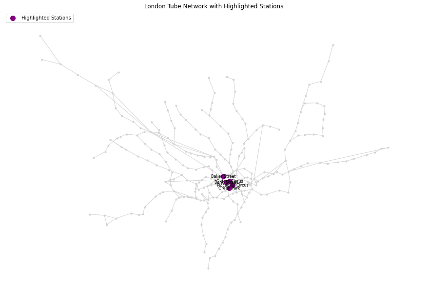

```python
# Calculate closeness centrality for all nodes and sort
closeness_centrality = nx.closeness_centrality(G, distance='dist')
top_closeness_stations = sorted(closeness_centrality.items(), key=lambda x: x[1], reverse=True)[:5]

# Print top 5
print("Top 5 stations with highest closeness centrality:")
for node, centrality in top_closeness_stations:
    station_name = labels.get(node, "Unknown Station")
    print(f"Node: {node} ({labels[node]}), Closeness Centrality: {centrality:.4f}")

top_closeness_ids = [station[0] for station in top_closeness_stations]
plot_highlighted_stations(G, pos_geo, top_closeness_ids, labels)
```

**Betweenness Centrality: Nodes**

With hubs as the most important stations in the network, betweenness centrality as the percentage of shortest paths from all pairs of nodes going through a specifif node is interesting as hubs are expected to have a high value for this measure by connecting different metro lines. As expected, the top 5 stations are similiar to those from the top 5 stations by degree and represent known hub stations where multiple lines connect.

```
Top 5 stations with highest betweenness centrality:
Node: 280 (Baker Street), Betweenness Centrality: 0.3052
Node: 409 (Liverpool Street), Betweenness Centrality: 0.2675
Node: 400 (King's Cross St. Pancras), Betweenness Centrality: 0.2555
Node: 333 (Earl's Court), Betweenness Centrality: 0.2218
Node: 441 (London Paddington), Betweenness Centrality: 0.2008
```

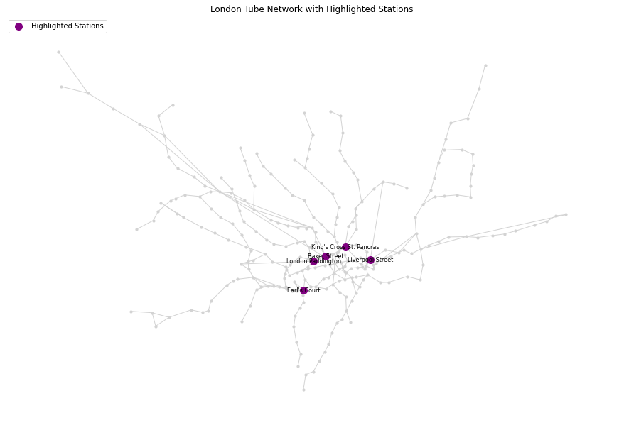

```python
# Calculate betweenness centrality for all nodes and sort
betweenness_centrality = nx.betweenness_centrality(G, weight='dist')
top_betweenness_stations = sorted(betweenness_centrality.items(), key=lambda x: x[1], reverse=True)[:5]

# Print top 5
print("Top 5 stations with highest betweenness centrality:")
for node, centrality in top_betweenness_stations:
    station_name = labels.get(node, "Unknown Station")
    print(f"Node: {node} ({labels[node]}), Betweenness Centrality: {centrality:.4f}")

plot_highlighted_stations(G, pos_geo, [station[0] for station in top_betweenness_stations], labels)
```

**Eigenvector Centrality**

```
Top 5 stations with highest eigenvector centrality:
Node: 440 (Oxford Circus), Eigenvector Centrality: 0.3744
Node: 294 (Bond Street), Eigenvector Centrality: 0.3369
Node: 362 (Green Park), Eigenvector Centrality: 0.3289
Node: 497 (Tottenham Court Road), Eigenvector Centrality: 0.2764
Node: 280 (Baker Street), Eigenvector Centrality: 0.2738
```

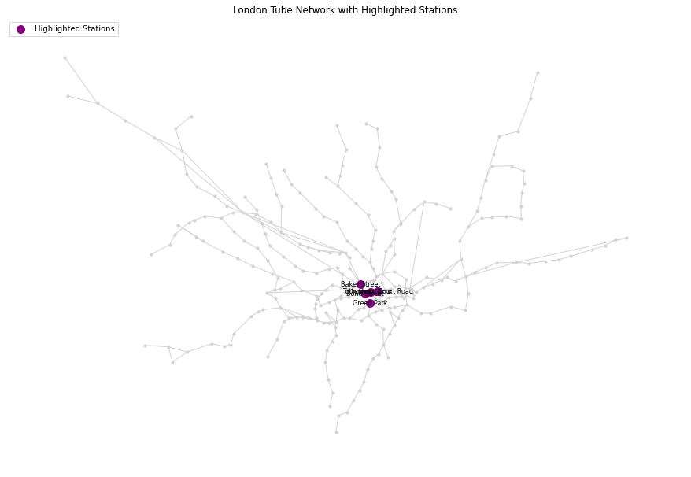

```python
# Calculate eigenvector centrality and get top 5 nodes
eigenvector_centrality = nx.eigenvector_centrality(G, max_iter=1000)
top_eigenvector_stations = sorted(eigenvector_centrality.items(), key=lambda x: x[1], reverse=True)[:5]

print("Top 5 stations with highest eigenvector centrality:")
for node, centrality in top_eigenvector_stations:
    station_name = labels.get(node, "Unknown Station")
    print(f"Node: {node} ({station_name}), Eigenvector Centrality: {centrality:.4f}")

plot_highlighted_stations(
    G,
    pos_geo,
    [node for node, _ in top_eigenvector_stations],
    labels
)
```

**Pagerank**

```
Top 5 stations with highest PageRank:
Node: 371 (Harrow-on-the-Hill), PageRank: 0.0097
Node: 400 (King's Cross St. Pancras), PageRank: 0.0088
Node: 280 (Baker Street), PageRank: 0.0079
Node: 441 (London Paddington), PageRank: 0.0079
Node: 333 (Earl's Court), PageRank: 0.0073
```

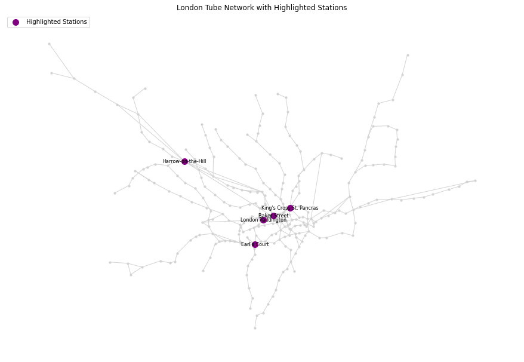

```python
# Calculate PageRank for all nodes
pagerank = nx.pagerank(G)
top_pagerank_stations = sorted(pagerank.items(), key=lambda x: x[1], reverse=True)[:5]

print("Top 5 stations with highest PageRank:")
for node, rank in top_pagerank_stations:
    station_name = labels.get(node, "Unknown Station")
    print(f"Node: {node} ({station_name}), PageRank: {rank:.4f}")

# Plot
top_pagerank_ids = [station[0] for station in top_pagerank_stations]
plot_highlighted_stations(G, pos_geo, top_pagerank_ids, labels)
```

**Betweenness Centrality: Edges**

As done previously for nodes, for Edges the betweenness centrality can be evaluated finding the most used edges when going from all nodes to every other nodes via the shortest path. While this might give insights into the most used network sections for a evenly used transportation network, overall the meaning of this network is not as significant as for the nodes as the traffic on specific edges will depend more on the points of interest in the city of london than on the theoretical shortest paths to all other points. None the less, unsurprisinly, many of the top 5 Edges start/end in a previously as central identified node.

```python
# Calculate top 5 Edges via Betweenness centrality
edge_betweenness_centrality = nx.edge_betweenness_centrality(G)
top_betweenness_edges = sorted(edge_betweenness_centrality.items(), key=lambda x: x[1], reverse=True)[:5]

print("Top 5 edges with highest betweenness centrality:")
for edge, centrality in top_betweenness_edges:
    station_1 = labels.get(edge[0], "Unknown Station")
    station_2 = labels.get(edge[1], "Unknown Station")
    print(f"Edge: {edge} (Connecting {station_1} and {station_2}), Betweenness Centrality: {centrality:.4f}")
```

```
Top 5 edges with highest betweenness centrality:
Edge: ('280', '341') (Connecting Baker Street and Edgware Road), Betweenness Centrality: 0.2545
Edge: ('341', '441') (Connecting Edgware Road and London Paddington), Betweenness Centrality: 0.2515
Edge: ('280', '294') (Connecting Baker Street and Bond Street), Betweenness Centrality: 0.2094
Edge: ('331', '441') (Connecting Ealing Broadway and London Paddington), Betweenness Centrality: 0.1911
Edge: ('280', '360') (Connecting Baker Street and Great Portland Street), Betweenness Centrality: 0.1722
```

### Network Cohesion

#### Local Density

**Distribution of Clique Sizes**

The analysis of clique sizes in the "London Underground Network" it is performed to reveal important structural characteristics of the system. The network contains 276 cliques of size 2, which correspond to direct connections between pairs of stations, as mentioned before, one station will mostly have just 2 neighbours, the next and the previous station, therefore this number is expected, most of the stations with 2 cliques. These pairwise connections form the basic structure of the "London Underground Network", reflecting its efficient, metro line and arms design where stations serve as sequential stops along each line.

In the other hand, only 17 cliques of size 3 were identified, indicating that fully interconnected groups of three stations, where each station is directly connected to the other two are rare. These triangular structures are more likely to occur in densely connected hubs or transfer points, such as central London or areas like Heathrow Airport, where multiple lines intersect. This low presence of cliques of size 3 reinforces the idea that the network as being a transportation network, is not highly meshed, but rather a tree design with arms that encounters in the center of the city as mentioned and shown in the previous part of the analysis. This pattern also contributes toa simplicity and efficiency system for the metro in the city, where passengers can reach any point of the network where transfers are possible in central stations or nodes.

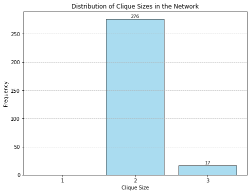

```python
# Get cliques
cliques = list(nx.find_cliques(G))
clique_sizes = [len(clique) for clique in cliques]

# plot dist
plt.figure(figsize=(8, 6))
bars = plt.bar(range(1, max(clique_sizes) + 1),
               [clique_sizes.count(i) for i in range(1, max(clique_sizes) + 1)],
               width=0.8,
               edgecolor='black',
               color='skyblue',
               alpha=0.7)

# cosmetics
plt.title('Distribution of Clique Sizes in the Network')
plt.xlabel('Clique Size')
plt.ylabel('Frequency')
plt.xticks(range(1, max(clique_sizes) + 1))
plt.grid(axis='y', linestyle='--', alpha=0.7)

for bar in bars:
    height = bar.get_height()
    if height > 0:
        plt.text(bar.get_x() + bar.get_width() / 2, height + 0.5, str(int(height)), ha='center', va='bottom', fontsize=9)
plt.show()
```

```python
# Maximal cliques
maximal_cliques = list(nx.find_cliques(G))
clique_sizes = [len(clique) for clique in maximal_cliques]

max_clique_size = max(clique_sizes)
largest_cliques = [clique for clique in maximal_cliques if len(clique) == max_clique_size]

# Print
print(f"Number of maximal cliques: {len(largest_cliques)}")
print(f"Size of the largest clique: {max_clique_size}")
print(f"Largest clique(s): {largest_cliques}")
```

[output not shown]

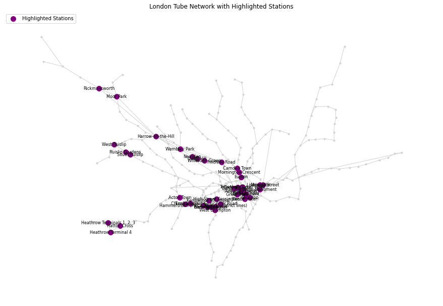

```python
nodes_in_largest_cliques = set(node for clique in largest_cliques for node in clique)
plot_highlighted_stations(G, pos_geo, list(nodes_in_largest_cliques), labels)
```

**Graph Coreness (K-Cores)**

When evaluating the Graph Coreness, we find as expected that only subgraphs up to k=2 can be created, in line with the tree structure of the Network. The existing stations with higher degree (hubs) are isolated as they connect to each other by lower degree stations, meaning they can not generate a subgraph. This gives a intuitive explonation of why metro systems are highly sensitive to break downs, as there is a large amount of critical points that, if cut, will reduce connectivity significantly.

```
Number of nodes in each k-core:
k = 1: 268 nodes
```

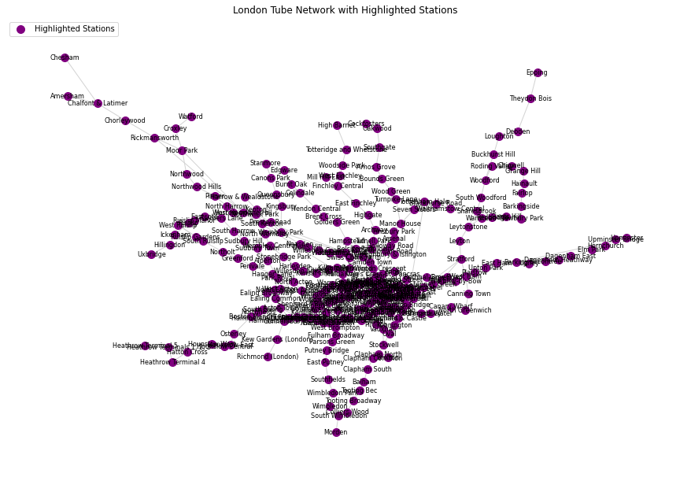

```
k = 2: 175 nodes
```

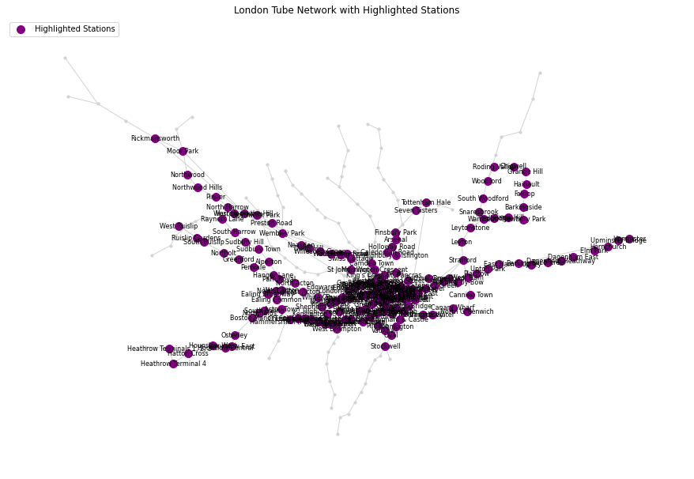

```
k = 3: 0 nodes
```

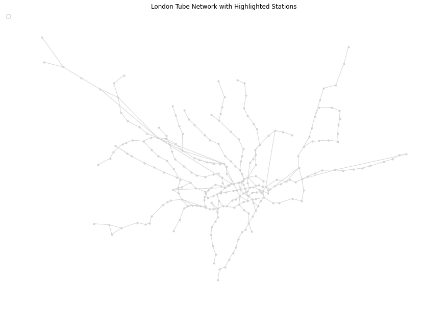

```python
# Calculate the k-core for different values of k
k_core_dict = {}
for k in range(1, 4):
    k_core = nx.k_core(G, k=k)
    k_core_dict[k] = k_core

# Print the number of nodes in each k-core
print("Number of nodes in each k-core:")
for k, subgraph in k_core_dict.items():
    print(f"k = {k}: {len(subgraph.nodes())} nodes")

    # plot
    stations_kn = list(k_core_dict[k].nodes())
    plot_highlighted_stations(G, pos_geo, stations_kn, labels)
```

**Density**

The the density of the "London Underground Network" is relatively small, which is in line with the tree like structure and the fact that the majority of nodes have a degree 2, as previously discussed in relation to the adjecency Matrix. Once again, the result is directly related to the design of the transportation network where the metro lines forms the arms as linear routes, prioritizing clarity and simplicity navigation. The low density shows an small fraction of all possible connections.

```python
# Calculate the density of the network
density = nx.density(G)
print(f"Density of the network: {density:.4f}")
```

```
Density of the network: 0.0091
```

**Clustering Coefficent**

Due to the network's low density, the clustering coefficient as existing triangles devided by possible triangles in the network is also very low, this is supported by the small number of observed 3-cliques (only 17 in total), indicating that fully connected triplets of stations are rare. This is in line with the low connectivity already identified.

```python
# Calculate the global clustering coefficient (transitivity) of the network
global_clustering_coefficient = nx.transitivity(G)
print(f"Global clustering coefficient of the network: {global_clustering_coefficient:.4f}")
```

```
Global clustering coefficient of the network: 0.0813
```

**Small World Property**

With a low clustering coefficient but a fairly long average shortest path, it can be concluded that the "London Underground Network" does not hold the small world property. This again is in line with the tree structure, meaning that many stations have to be passed to reach the outer areas of the metro network, with no direct connections available. This might however change if additional transportation networks like regional trains or express busses would be considered, which may provide cross-connections that reduce travel distances and increase local clustering, bringing the network closer to small-world behavior.

```python
actual_avg_shortest_path_length = nx.average_shortest_path_length(G)
print(f"Average Shortest Path Length: {actual_avg_shortest_path_length:.4f}")
```

```
Average Shortest Path Length: 12.4380
```

### Community Detection

The objective of the following section is to define the optimal graph partition. This will be measured using modularity, which quantifies the quality of the partition. A higher modularity value indicates a better partition, with values approaching 1 representing strong community structure, while values closer to -1 suggest poor or weak partitions.

**Optimal Modularity**: *Alternatively* **Greddy Modularity Algorithm**

As previously mentioned, the goal is to identify the partition that maximizes modularity. The following code implements the optimal algorithm. However, due to the size of the "London Underground Network", running this algorithm has an exponential time complexity, making it computationally expensive.

```python
# #If G is a networkx graph
# G_nx = G

# #Convert to igraph
# G_ig = ig.Graph.TupleList(G_nx.edges(), directed=False)

# #Run community detection
# clusters = G_ig.community_optimal_modularity()

# #rint community membership
# print(clusters.membership)
```

As previously mentioned, the goal is to identify the partition that maximizes modularity. The following code implements the optimal algorithm. However, due to the size of the "London Underground Network", running this algorithm has an exponential time complexity, making it computationally expensive.

Therefore, the next algorithm to be used is Greedy Modularity, which aims to efficiently approximate the division of the network into communities by maximizing modularity in a computationally feasible manner. Although it does not guarantee the same result as the optimal modularity algorithm, it is suitable for large networks like ours and provides an acceptable level of accuracy.

The algorithm detected 15 communities, a reasonable number considering that the "London Underground Network" is based on metro lines. As mentioned in the introduction, the network consists of 11 metro lines, as well as other lines (such as Light Rail and Regional Lines). The modularity value of 0.8192 further suggests a good construction of communities within the network.

Interestingly, when analyzing the graph, we observe that the main difference between the communities and the real metro lines is that, once reaching the center of the map, the communities diverge into different groups. This contrasts with the real metro lines, which extend from one extreme of the city to the other. This is an intriguing feature of the algorithm, as it identifies communities that are not necessarily aligned with the physical metro line structure.

```
Number of communities detected: 15
Modularity: 0.8192
```

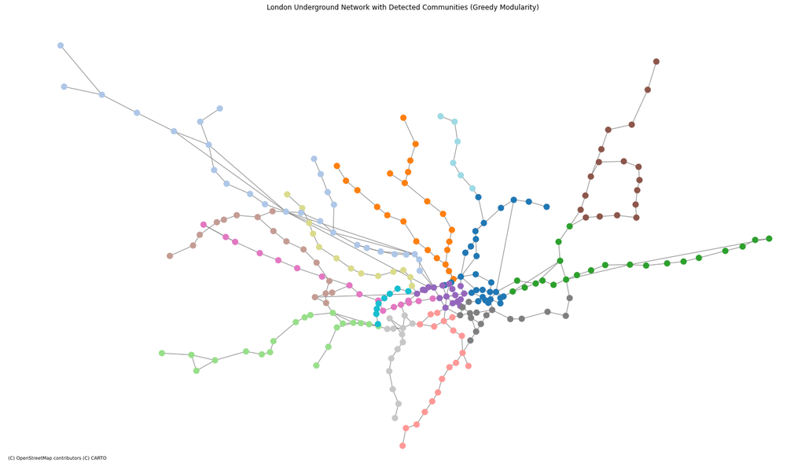

```python
# Compute communities using greedy modularity
communities = list(greedy_modularity_communities(G))

community_mapping = {node: idx for idx, community in enumerate(communities) for node in community}
nx.set_node_attributes(G, community_mapping, 'community')

# Print
print(f"Number of communities detected: {len(communities)}")
print(f"Modularity: {modularity(G, communities):.4f}")


# Plot
colors = [community_mapping[node] for node in G.nodes()]
fig, ax = plt.subplots(figsize=(25, 25))
ctx.add_basemap(ax, crs="EPSG:4326", source=ctx.providers.CartoDB.Positron, zoom=10)

nx.draw(G, pos=pos_geo, with_labels=False, node_size=100,
        node_color=colors, cmap=plt.cm.tab20, edge_color='gray', ax=ax)

ax.set_xlim(-0.68, 0.29)
ax.set_ylim(51.39, 51.73)
ax.set_aspect(1 / np.cos(np.radians((51.4 + 51.73) / 2)))

plt.title("London Underground Network with Detected Communities (Greedy Modularity)")
plt.show()
```

**Fast Greedy Algorithm**

To simplify the integer programming proposed by the optimal modularity algorithm, which cannot be run on our network due to its computational complexity, the Fast Greedy algorithm will be applied to the "London Underground Network".

In this case, the algorithm yields a slightly better modularity value than the previous Greedy Modularity algorithm. However, both algorithms converge to detect 15 communities, with a similar pattern in the layout map. The communities are primarily located in the parts of the metro lines outside the city center, while the stations in the city center form distinct communities, possibly based on their connectivity to other stations.

```
Number of communities detected: 15
Modularity: 0.8196
```

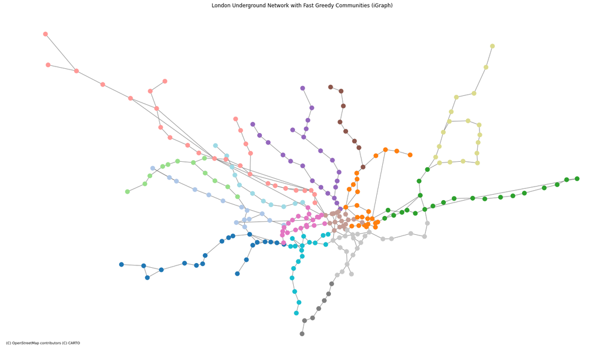

```python
# Convert to iGraph
edges = list(G.edges())
ig_graph = ig.Graph.TupleList(edges, directed=False)

# Run Fast Greedy community detection
communities = ig_graph.community_fastgreedy()
clusters = communities.as_clustering()

ig_to_nx = {i: v["name"] for i, v in enumerate(ig_graph.vs)}
nx_community_mapping = {ig_to_nx[i]: clusters.membership[i] for i in range(len(clusters.membership))}
nx.set_node_attributes(G, nx_community_mapping, 'community')

# Print
print(f"Number of communities detected: {len(clusters)}")
print(f"Modularity: {clusters.modularity:.4f}")

# Plot over map using pos_geo and community colors
colors = [nx_community_mapping[node] for node in G.nodes()]

fig, ax = plt.subplots(figsize=(25, 25))
ctx.add_basemap(ax, crs="EPSG:4326", source=ctx.providers.CartoDB.Positron, zoom=10)

nx.draw(
    G, pos=pos_geo, with_labels=False, node_size=100,
    node_color=colors, cmap=plt.cm.tab20, edge_color='gray', ax=ax
)

ax.set_xlim(-0.68, 0.29)
ax.set_ylim(51.39, 51.73)
ax.set_aspect(1 / np.cos(np.radians((51.4 + 51.73) / 2)))

plt.title("London Underground Network with Fast Greedy Communities (iGraph)")
plt.show()
```

**Louvain Algorithm**

As an alternative, the Louvain Algorithm can also be used to find the partition that maximizes modularity without the need to run an optimization algorithm.

Similarly, the communities identified by the Louvain algorithm appear to represent the "arms" of the network. These can be interpreted as the metro lines or stations located in the outer areas of the city center. Within the city center, one to three communities are identified, possibly based on their connectivity to key junction stations that serve as transfer points for passengers.

```
Number of communities detected: 15
Modularity of the detected community structure: 0.8268
```

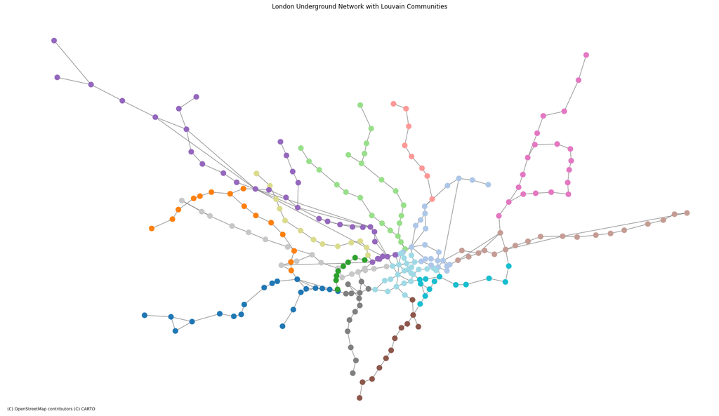

```python
# Perform Louvain community detection
partition = community_louvain.best_partition(G, weight='weight')  # Use None if no weights
nx.set_node_attributes(G, partition, 'community')

# Print
num_communities = len(set(partition.values()))
print(f"Number of communities detected: {num_communities}")

# Compute modularity
modularity_value = community_louvain.modularity(partition, G, weight='weight')
print(f"Modularity of the detected community structure: {modularity_value:.4f}")

# Plot on London map
community_colors = [partition[node] for node in G.nodes()]
fig, ax = plt.subplots(figsize=(25, 25))
ctx.add_basemap(ax, crs="EPSG:4326", source=ctx.providers.CartoDB.Positron, zoom=10)

nx.draw(
    G,
    pos=pos_geo,
    node_color=community_colors,
    with_labels=False,
    node_size=100,
    cmap=plt.cm.tab20,
    edge_color='gray',
    ax=ax
)

ax.set_xlim(-0.68, 0.29)
ax.set_ylim(51.39, 51.73)
ax.set_aspect(1 / np.cos(np.radians((51.4 + 51.73) / 2)))

plt.title("London Underground Network with Louvain Communities")
plt.show()
```

**Label Propagation Algorithm**

The Label Propagation Algorithm takes into account the neighbors of each vertex for community detection, making it a useful option for large networks, such as the one in this analysis of the "London Underground Network".

The result of applying this algorithm yields 77 communities with a significantly reduced modularity of 0.62, which indicates worse community detection compared to the previous algorithms. Additionally, the large number of communities, 77, is not well-defined, as there are no clear breaks in the network that would correspond to such a fragmented division of metro lines. This suggests that the algorithm is identifying communities based on smaller groups of stations, with each community containing roughly 4 stations. This is likely due to the algorithm's tendency to over-segment the network, possibly focusing on local neighborhoods in the city rather than larger areas of London.

```
Number of communities detected: 77
Modularity of the detected community structure: 0.6271
```

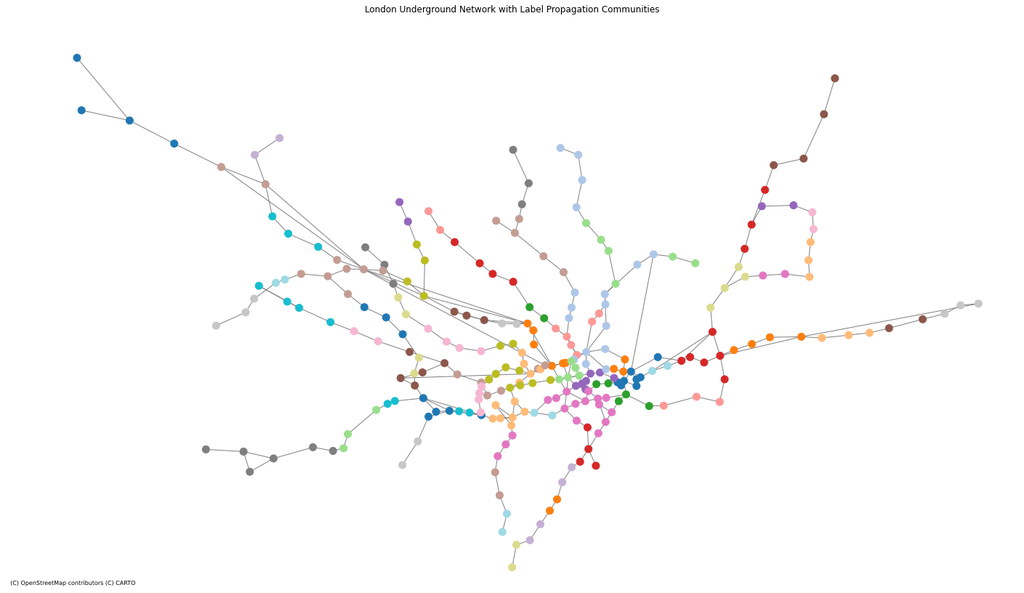

```python
# Detect communities using Label Propagation
communities = list(label_propagation_communities(G))

community_mapping = {node: idx for idx, community in enumerate(communities) for node in community}
nx.set_node_attributes(G, community_mapping, 'community')

# Print results
print(f"Number of communities detected: {len(communities)}")

# Compute modularity
modularity_value = modularity(G, communities)
print(f"Modularity of the detected community structure: {modularity_value:.4f}")

# Plot
fig, ax = plt.subplots(figsize=(25, 25))
ctx.add_basemap(ax, crs="EPSG:4326", source=ctx.providers.CartoDB.Positron, zoom=10)

community_colors = [community_mapping[node] for node in G.nodes()]


nx.draw(
    G,
    pos=pos_geo,
    node_color=community_colors,
    with_labels=False,
    node_size=100,
    cmap=plt.cm.tab20,
    edge_color='gray',
    ax=ax
)

ax.set_xlim(-0.68, 0.29)
ax.set_ylim(51.39, 51.73)
ax.set_aspect(1 / np.cos(np.radians((51.4 + 51.73) / 2)))

plt.title("London Underground Network with Label Propagation Communities")
plt.show()
```